# Predicting the Quality of a Workout

Ben Kling

4/15/2022

## Predicting Quality of a workout

In this project, we will attempt to use statistical learning to make predictions about the manner in which a user performed an exercise. We are given data from accelerometers that take measurements from the belt, forearm, arm, and dumbbell.

The goal is to accurately predict a value called “classe” given a sample of 19,622 labelled observations.

## Data input and Cleaning

The data set requires us to do some cleaning to ensure it is ready to be modeled properly. Brief outline of cleaning steps taken:

- Coerced all features to numeric - there were many NA values and many values that appear to be artifacts of storage in excel (“#DIV/0” values)
- replaced NA values with 0 - models need to interpret all values as continuous and without replacing to zero these observations would be ignored.
- removed features that have no non-zero values: 9 potential features are completely absent of any observed data. These need to be removed prior to the execution of the data to prevent complications during modeling

In addition to cleaning the data, we will also partition the data known as the “training” data into two sets:

- 80% to train the model
- 20% to test the model and estimate out of sample error, prior to applying the model against the 20 evaluation observations

```r
# #DIV/0! values
data <- rawdata %>%
    mutate(across(.fns=na_if, y="#DIV/0!")) %>% # lots of "#DIV/0" errors in the data (excel output?)
    mutate(across(.cols = -c(1:7,160), .fns = as.numeric)) %>% # Coerce to numeric
    mutate(across(.cols = -c(1:7,160), .fns = replace_na, replace=0)) %>% # zero out the NA values
    filter(!is.na(classe)) %>% # remove NA classe values
    mutate(classe = as.factor(classe)) # convert classe to a factor


evaluationdata <- evaluationraw %>%
    mutate(across(.fns=na_if, y="#DIV/0!")) %>% # lots of "#DIV/0" errors in the data (excel output?)
    mutate(across(.cols = -c(1:7,160), .fns = as.numeric)) %>% # Coerce to numeric
    mutate(across(.cols = -c(1:7,160), .fns = replace_na, replace=0)) # zero out the NA values




# these features have ONLY ZERO values
allzero <- c('kurtosis_yaw_belt',
             'skewness_yaw_belt',
             'amplitude_yaw_belt',
             'kurtosis_yaw_dumbbell',
             'skewness_yaw_dumbbell',
             'amplitude_yaw_dumbbell',
             'kurtosis_yaw_forearm',
             'skewness_yaw_forearm',
             'amplitude_yaw_forearm')

data <- data %>%
    select(-allzero)

evaluationdata <- evaluationdata %>%
    select(-allzero)

# first 7 variables are not measurements, merely attributes and can be ignored
data_processed <- data %>% select(-(1:7))
evaluation_processed <- evaluationdata %>% select(-(1:7))


# hold out 20 % of training data for validation purposes, to estimate out of
# sample error

# set seed for reproducibility
set.seed(1234)

trainIndex <- createDataPartition(data_processed$classe,
                                  p=0.8,
                                  list=FALSE,
                                  times=1
                                  )

train_data <- data_processed[trainIndex,]
test_data <- data_processed[-trainIndex,]
```

## Analysis

### Exploratory Data Analysis

Prior to selecting a model, we run some exploratory data analysis to determine what the structure of the data is that we are looking at as well as visualizing distribution of the features across the labelled data. I’ve also included some code from QA against the data to ensure it was cleaned prioperly.

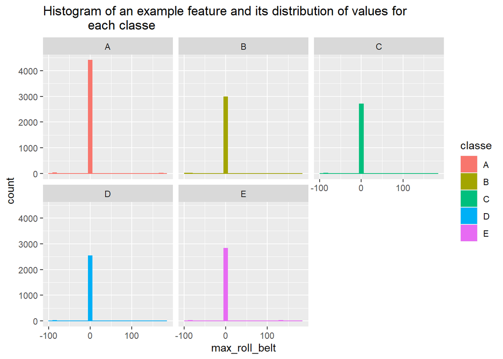

```r
g <- ggplot(train_data, mapping = aes(max_roll_belt, fill=classe, color=classe))
g +
    geom_histogram() +
    facet_wrap(~classe) +
    ggtitle("Histogram of an example feature and its distribution of values for
            each classe")
```

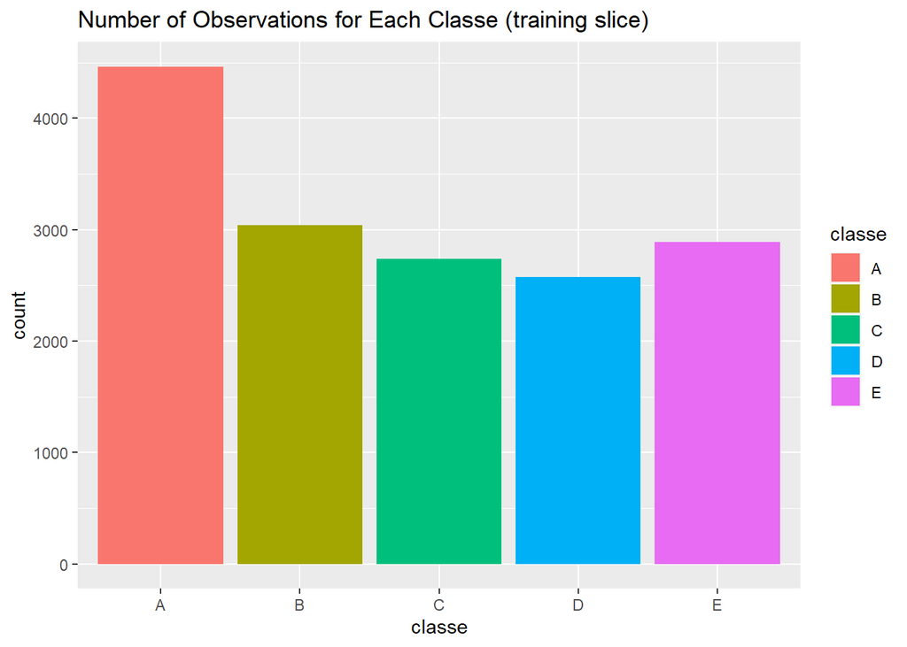

```r
g <- ggplot(train_data, mapping = aes(classe, fill=classe))
g +
    geom_histogram(stat="count") +
    ggtitle("Number of Observations for Each Classe (training slice)")
```

### Model Selection

Given that this is a classification problem, I have chosen to use a random forest model with which to build a prediction. There are many possible models to choose from, but with how robust of a sample that we are given it is likely that many models will perform well.

```r
# apply pca
# run random forest on the reduced feature set
# parallellize the execution

set.seed(1234) #set a seed for reproducibility

cluster <- makeCluster(detectCores() - 1) # convention to leave 1 core for OS
registerDoParallel(cluster)

fitCtrl <- trainControl(method='cv',
                        number=5,
                        allowParallel=TRUE)

rfmodel <- train(classe ~.,
                 data=train_data,
                 method='rf',
                 trControl=fitCtrl)

stopCluster(cluster)
registerDoSEQ()
```

### Model Parameters & Performance

In addition to selecting random forest as our model of choice, we also are applying k-fold cross-validation to the result set, with 5 folds.

After running the model using the “caret” package, we see that the optimal value for the only tuning parameter (mtry) is 72, which produces a 99.3% accuracy on the training set

*Accuracy - in sample, out of sample* Upon running the model, we see the following for accuracy:

```r
rfmodel
```

```
## Random Forest
##
## 15699 samples
##   143 predictor
##     5 classes: 'A', 'B', 'C', 'D', 'E'
##
## No pre-processing
## Resampling: Cross-Validated (5 fold)
## Summary of sample sizes: 12559, 12561, 12560, 12557, 12559
## Resampling results across tuning parameters:
##
##   mtry  Accuracy   Kappa
##     2   0.8808838  0.8484832
##    72   0.9928661  0.9909752
##   143   0.9847756  0.9807397
##
## Accuracy was used to select the optimal model using the largest value.
## The final value used for the model was mtry = 72.
```

```r
rfmodel$resample
```

```
##    Accuracy     Kappa Resample
## 1 0.9955414 0.9943600    Fold1
## 2 0.9917171 0.9895217    Fold3
## 3 0.9952199 0.9939535    Fold2
## 4 0.9894904 0.9867047    Fold5
## 5 0.9923616 0.9903360    Fold4
```

```r
confusionMatrix.train(rfmodel)
```

```
## Cross-Validated (5 fold) Confusion Matrix
##
## (entries are percentual average cell counts across resamples)
##
##           Reference
## Prediction    A    B    C    D    E
##          A 28.4  0.2  0.0  0.0  0.0
##          B  0.0 19.1  0.1  0.0  0.0
##          C  0.0  0.0 17.2  0.2  0.0
##          D  0.0  0.0  0.1 16.2  0.1
##          E  0.0  0.0  0.0  0.0 18.3
##
##  Accuracy (average) : 0.9929
```

We held out a group of the training data to estimate our out of sample accuracy as well, given how robust of a dataset we had.

**Out of sample Accuracy:** 99.3%

**Confusion Matrix:**

```r
pred <- predict(rfmodel,
                test_data)

confusionMatrix(test_data$classe,pred)
```

```
## Confusion Matrix and Statistics
##
##           Reference
## Prediction    A    B    C    D    E
##          A 1116    0    0    0    0
##          B    5  753    1    0    0
##          C    0    2  680    2    0
##          D    0    0   11  630    2
##          E    0    0    2    3  716
##
## Overall Statistics
##
##                Accuracy : 0.9929
##                  95% CI : (0.9897, 0.9953)
##     No Information Rate : 0.2858
##     P-Value [Acc > NIR] : < 2.2e-16
##
##                   Kappa : 0.991
##
##  Mcnemar's Test P-Value : NA
##
## Statistics by Class:
##
##                      Class: A Class: B Class: C Class: D Class: E
## Sensitivity            0.9955   0.9974   0.9798   0.9921   0.9972
## Specificity            1.0000   0.9981   0.9988   0.9960   0.9984
## Pos Pred Value         1.0000   0.9921   0.9942   0.9798   0.9931
## Neg Pred Value         0.9982   0.9994   0.9957   0.9985   0.9994
## Prevalence             0.2858   0.1925   0.1769   0.1619   0.1830
## Detection Rate         0.2845   0.1919   0.1733   0.1606   0.1825
## Detection Prevalence   0.2845   0.1935   0.1744   0.1639   0.1838
## Balanced Accuracy      0.9978   0.9977   0.9893   0.9941   0.9978
```

**Predictions against the evaluation (unlabelled) set**

Here we run some code to see what the model chose for predicting each of the 20 unlabelled observations:

```r
eval_pred <- predict(rfmodel,
                     evaluation_processed)

# print predictions
i <- 1
for (j in eval_pred) {
    print(paste0(i," ", j))
    i <- i + 1
}
```

```
## [1] "1 B"
## [1] "2 A"
## [1] "3 B"
## [1] "4 A"
## [1] "5 A"
## [1] "6 E"
## [1] "7 D"
## [1] "8 B"
## [1] "9 A"
## [1] "10 A"
## [1] "11 B"
## [1] "12 C"
## [1] "13 B"
## [1] "14 A"
## [1] "15 E"
## [1] "16 E"
## [1] "17 A"
## [1] "18 B"
## [1] "19 B"
## [1] "20 B"
```

*Performance Notes*

Running the random forest modeling initially was very slow. In order to produce results quicker, we replaced bootstrap resampling (very laborious) with cross-validation. In addition we used the doParallel package to allow the model to be trained with parallel computing. This sped up the runtime from indefinitely long, to just a minute or two.

### Citations and References

All data in this analysis was made available here: https://web.archive.org/web/20161224072740/http:/groupware.les.inf.puc-rio.br/har An excellent guide to parallelizing model training by Leonard Greski, here https://github.com/lgreski/datasciencectacontent/blob/master/markdown/pml-randomForestPerformance.md